# Project_2_EDA

Satvik Ajmera

4. Relevant Information:

   The data is related with direct marketing campaigns of a Portuguese banking institution. The marketing campaigns were based on phone calls. Often, more than one contact to the same client was required, in order to access if the product (bank term deposit) would be (or not) subscribed.

   There are two datasets:
   1. bank-full.csv with all examples, ordered by date (from May 2008 to November 2010).
   2. bank.csv with 10% of the examples (4521), randomly selected from bank-full.csv. The smallest dataset is provided to test more computationally demanding machine learning algorithms (e.g. SVM).

   The classification goal is to predict if the client will subscribe a term deposit (variable y).
5. Number of Instances: 45211 for bank-full.csv (4521 for bank.csv)
6. Number of Attributes: 16 + output attribute.
7. Attribute information:

   For more information, read [Moro et al., 2011].

   Input variables: # bank client data: 1 - age (numeric) 2 - job : type of job (categorical: “admin.”,“unknown”,“unemployed”,“management”,“housemaid”,“entrepreneur”,“student”, “blue-collar”,“self-employed”,“retired”,“technician”,“services”) 3 - marital : marital status (categorical: “married”,“divorced”,“single”; note: “divorced” means divorced or widowed) 4 - education (categorical: “unknown”,“secondary”,“primary”,“tertiary”) 5 - default: has credit in default? (binary: “yes”,“no”) 6 - balance: average yearly balance, in euros (numeric) 7 - housing: has housing loan? (binary: “yes”,“no”) 8 - loan: has personal loan? (binary: “yes”,“no”) # related with the last contact of the current campaign: 9 - contact: contact communication type (categorical: “unknown”,“telephone”,“cellular”) 10 - day: last contact day of the month (numeric) 11 - month: last contact month of year (categorical: “jan”, “feb”, “mar”, …, “nov”, “dec”) 12 - duration: last contact duration, in seconds (numeric) # other attributes: 13 - campaign: number of contacts performed during this campaign and for this client (numeric, includes last contact) 14 - pdays: number of days that passed by after the client was last contacted from a previous campaign (numeric, -1 means client was not previously contacted) 15 - previous: number of contacts performed before this campaign and for this client (numeric) 16 - poutcome: outcome of the previous marketing campaign (categorical: “unknown”,“other”,“failure”,“success”)

Output variable (desired target): 17 - y - has the client subscribed a term deposit? (binary: “yes”,“no”)

8. Missing Attribute Values: None

```r
summary(bank_full)
```

```
      age                 job           marital          education     default        balance
 Min.   :18.00   blue-collar:9732   divorced: 5207   primary  : 6851   no :44396   Min.   : -8019
 1st Qu.:33.00   management :9458   married :27214   secondary:23202   yes:  815   1st Qu.:    72
 Median :39.00   technician :7597   single  :12790   tertiary :13301               Median :   448
 Mean   :40.94   admin.     :5171                    unknown  : 1857               Mean   :  1362
 3rd Qu.:48.00   services   :4154                                                  3rd Qu.:  1428
 Max.   :95.00   retired    :2264                                                  Max.   :102127
                 (Other)    :6835
 housing      loan            contact           day            month          duration
 no :20081   no :37967   cellular :29285   Min.   : 1.00   may    :13766   Min.   :   0.0
 yes:25130   yes: 7244   telephone: 2906   1st Qu.: 8.00   jul    : 6895   1st Qu.: 103.0
                         unknown  :13020   Median :16.00   aug    : 6247   Median : 180.0
                                           Mean   :15.81   jun    : 5341   Mean   : 258.2
                                           3rd Qu.:21.00   nov    : 3970   3rd Qu.: 319.0
                                           Max.   :31.00   apr    : 2932   Max.   :4918.0
                                                           (Other): 6060
    campaign          pdays          previous           poutcome       y
 Min.   : 1.000   Min.   : -1.0   Min.   :  0.0000   failure: 4901   no :39922
 1st Qu.: 1.000   1st Qu.: -1.0   1st Qu.:  0.0000   other  : 1840   yes: 5289
 Median : 2.000   Median : -1.0   Median :  0.0000   success: 1511
 Mean   : 2.764   Mean   : 40.2   Mean   :  0.5803   unknown:36959
 3rd Qu.: 3.000   3rd Qu.: -1.0   3rd Qu.:  0.0000
 Max.   :63.000   Max.   :871.0   Max.   :275.0000
```

response (y) has the client subscribed a term deposit? no: 39922 yes: 5289

[figure not shown]

```r
colnames(bank_full)
```

```
 [1] "age"       "job"       "marital"   "education" "default"   "balance"   "housing"   "loan"
 [9] "contact"   "day"       "month"     "duration"  "campaign"  "pdays"     "previous"  "poutcome"
[17] "y"
```

[figure not shown]

[output not shown]

[output cut: 866 more lines]

[output not shown]

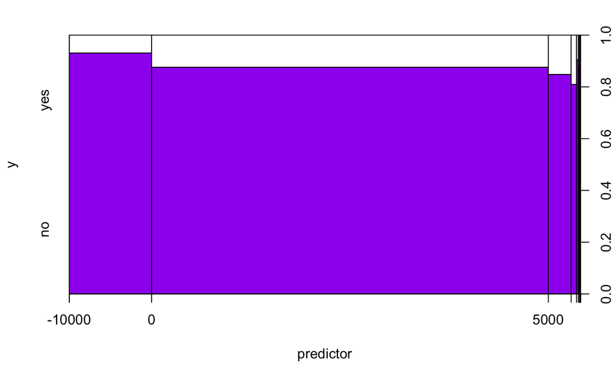

```r
proportion_plot(balance)
```

Output variable (desired target): 17 - y - has the client subscribed a term deposit? (binary: “yes”,“no”)

[figure not shown]

```r
table(q.prd,test$y)
```

```
q.prd    no   yes
  no  28524  3565
  yes  1689   433
```

```r
bonemed_fu
```

[output not shown]

[output not shown]